# Client Report - [Retail Analysis]

- Show All Code
- Hide All Code

Use Linear Regression to Predict Walmart’s Weekly Sales

Author

[Erin Hu]

```r
library(readr)
library(car)
library(tidyverse)
library(mosaic)
# library(reshape2)
library(readr)
library(plotly)
library(stringi)
library(ggplot2)
library(dplyr)
library(pander)
Features_data_set <- read_csv("~/Desktop/Featuresdataset.csv",
                              col_types = cols(Date = col_date(format = "%d/%m/%Y")))
# View(Features_data_set)

sales_data_set <- read_csv("~/Desktop/salesdataset.csv",
col_types = cols(Date = col_date(format = "%d/%m/%Y")))
#View(sales_data_set)

stores_data_set <- read_csv("~/Desktop/storesdataset.csv", show_col_types = FALSE)
#View(stores_data_set)
```

## Backgroung

I got the data from Kaggle about the Walmart stores located in different regions. Each store contains a number of departments, and my tasks is to predict the department-wide sales for each store.

In addition, Walmart runs several promotional markdown events throughout the year. These markdowns precede prominent holidays, the four largest of which are the Super Bowl, Labor Day, Thanksgiving, and Christmas. The weeks including these holidays are weighted five times higher in the evaluation than non-holiday weeks. Part of the challenge presented is modeling the effects of markdowns on these holiday weeks in the absence of complete/ideal historical data.

## Result

This is the summary of my linear model of Walmart Weekly sales, and the validation adjust R square is 0.395, which means my model is 39.5% close to the market price trend.

The math model I found to predict Walmart weekly sales is:

$$Y_i = \beta_0 + \beta_1 X_{MarkDown1} + \beta_2 X_{MarkDown2} + \beta_3 X_{MarkDown3} + \beta_4 X_{MarkDown5} \\
+ \beta_5 X_{CPIgroup2} + \beta_6 X_{CPIgroup3} + \beta_7 X_{CPIgroup4} \\
+ \beta_8 X_{Unemployment} \\
+ \beta_9 X_{Deptgroup2} + \beta_{10} X_{Deptgroup3} + \beta_{11} X_{Deptgroup4} + \beta_{12} X_{Deptgroup5}$$

The estimate model I found to predict Walmart weekly sales is:

$$\hat{Y} = -1392.556 + 0.1383814 X_{MarkDown1} + 0.05732099 X_{MarkDown2} + 0.1606509 X_{MarkDown3} \\
+ 0.1821851 X_{MarkDown5} + 6887.389 X_{CPIgroup2} + 6527.225 X_{CPIgroup3} \\
+ 5101.357 X_{CPIgroup4} - 454.8256 X_{Unemployment} \\
+ 4919.982 X_{Deptgroup2} + 11580.88 X_{Deptgroup3} \\
+ 16454.77 X_{Deptgroup4} + 37098.27 X_{Deptgroup5}$$

## Orginal Model

The model I use for this analysis is the estimated line model:

$$\underset{\text{estimated mean weekly sales}}{\hat{Y}_i} = b_0 + b_1 X_i \quad \underset{\text{estimated regression equation}}{}$$

## Analysis

For those curious about my model’s development process, here’s an overview:

Given the extensive dataset I obtained, consisting of 423,325 data entries spread across 99 departments, I sought to optimize my model’s alignment with market trends. To accomplish this, I segmented the departments into five groups based on their weekly sales and organized them into four CPI groups using the summarized values.

```r
sales_feature <- sales_data_set  |>
  full_join(Features_data_set, by = c("Date", "Store"))
#View(sales_feature)

sales_features_no_na <- sales_feature %>% replace(is.na(sales_feature), 0)

sales_features_no_na <- sales_features_no_na |>
  group_by(Dept) |>
    mutate(median= median(Weekly_Sales),
           dept_group=case_when(median < 3622~"group1",
                                median < 9253~"group2",
                                median < 14147~"group3",
                                median < 18249~"group4",
                                median < 61817~"group5"))

#View(sales_features_no_na)



sales_features_no_na <- sales_features_no_na |>
  group_by(CPI) |>
    mutate(median= median(CPI),
           CPI_group=case_when(CPI < 10~"1",
                                CPI < 150~"2",
                                CPI < 210~"3",
                                TRUE~"4"
                                ))


#View(sales_features_no_na)

sales_features_no_na <- sales_features_no_na |>
  mutate(IsHoliday.x = ifelse(IsHoliday.x %in% c("TRUE"),1,0))
```

```r
mylm8 <- lm(Weekly_Sales ~
              #I(Temperature^2) +
              MarkDown1 +
              MarkDown2 +
              MarkDown3 +
              MarkDown5 +
              CPI_group +
              Unemployment +
              dept_group,
            data = sales_features_no_na)
summary(mylm8)
```

```
Call:
lm(formula = Weekly_Sales ~ MarkDown1 + MarkDown2 + MarkDown3 +
    MarkDown5 + CPI_group + Unemployment + dept_group, data = sales_features_no_na)

Residuals:
    Min      1Q  Median      3Q     Max
-142863   -5566   -1137    2963  654601

Coefficients:
                   Estimate Std. Error t value Pr(>|t|)
(Intercept)      -1.393e+03  7.240e+02  -1.924   0.0544 .
MarkDown1         1.384e-01  4.887e-03  28.315  < 2e-16 ***
MarkDown2         5.732e-02  5.373e-03  10.669  < 2e-16 ***
MarkDown3         1.607e-01  4.829e-03  33.266  < 2e-16 ***
MarkDown5         1.822e-01  6.769e-03  26.915  < 2e-16 ***
CPI_group2        6.887e+03  7.370e+02   9.345  < 2e-16 ***
CPI_group3        6.527e+03  7.377e+02   8.848  < 2e-16 ***
CPI_group4        5.101e+03  7.347e+02   6.944 3.82e-12 ***
Unemployment     -4.548e+02  1.521e+01 -29.906  < 2e-16 ***
dept_groupgroup2  4.920e+03  7.547e+01  65.193  < 2e-16 ***
dept_groupgroup3  1.158e+04  8.942e+01 129.515  < 2e-16 ***
dept_groupgroup4  1.645e+04  1.061e+02 155.090  < 2e-16 ***
dept_groupgroup5  3.710e+04  7.689e+01 482.483  < 2e-16 ***
---
Signif. codes:  0 '***' 0.001 '**' 0.01 '*' 0.05 '.' 0.1 ' ' 1

Residual standard error: 17500 on 423312 degrees of freedom
Multiple R-squared:  0.4051,    Adjusted R-squared:  0.4051
F-statistic: 2.402e+04 on 12 and 423312 DF,  p-value: < 2.2e-16
```

## Validation

```r
set.seed(121)

num_rows <- 1000 #1460 total
keep <- sample(1:nrow(sales_features_no_na), num_rows)

mytrain <- sales_features_no_na[keep, ] #Use this in the lm(..., data=mytrain) it is like "rbdata"

mytest <- sales_features_no_na[-keep, ]

lm.all.train <- lm(Weekly_Sales ~
              #I(Temperature^2) +
              MarkDown1 +
              MarkDown2 +
              MarkDown3 +
              MarkDown5 +
              CPI_group +
              Unemployment +
              dept_group,
            data = mytrain)



yht <- predict(lm.all.train, newdata=mytest)

  # Compute y-bar
  ybar <- mean(mytest$Weekly_Sales) #Yi is given by Ynew from the new sample of data

  # Compute SSTO
  SSTO <- sum( (mytest$Weekly_Sales - ybar)^2 )

  # Compute SSE for each model using y - yhat
  SSEt <- sum( (mytest$Weekly_Sales - yht)^2 )


  # Compute R-squared for each
  rst <- 1 - SSEt/SSTO


  # Compute adjusted R-squared for each
  n <- length(mytest$Weekly_Sales) #sample size
  pt <- length(coef(lm.all.train)) #num. parameters in model

  rsta <- 1 - (n-1)/(n-pt)*SSEt/SSTO



my_output_table2 <- data.frame(Model = c("True"), `Original R2` = c( summary(lm.all.train)$r.squared), `Orig. Adj. R-squared` = c( summary(lm.all.train)$adj.r.squared), `Validation R-squared` = c(rst), `Validation Adj. R^2` = c(rsta))

colnames(my_output_table2) <- c("Model", "Original $R^2$", "Original Adj. $R^2$", "Validation $R^2$", "Validation Adj. $R^2$")

knitr::kable(my_output_table2, escape=TRUE, digits=4)
```

| Model | Original $R^2$ | Original Adj. $R^2$ | Validation $R^2$ | Validation Adj. $R^2$ |
| --- | --- | --- | --- | --- |
| True | 0.4254 | 0.4184 | 0.395 | 0.395 |

According to the table provided, the adjusted R-square for my validation stands at 39.5%. While it falls short of my desired outcome, it’s important to note that achieving a high validation score is challenging given the substantial size and complexity of the dataset. However, this could be an area for further exploration and improvement in the future.

## Residual Plots & Regression Assumptions

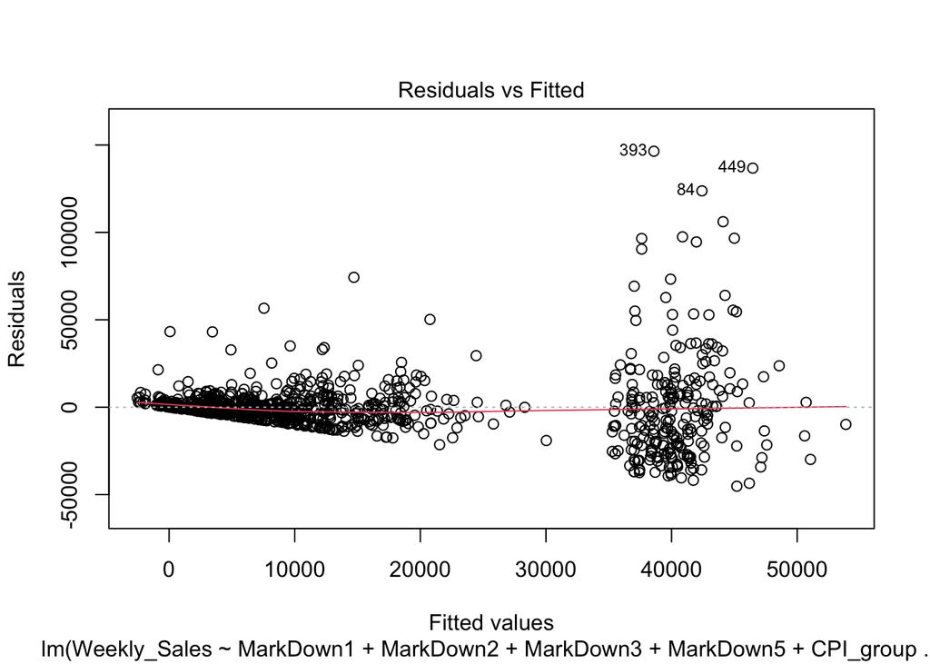

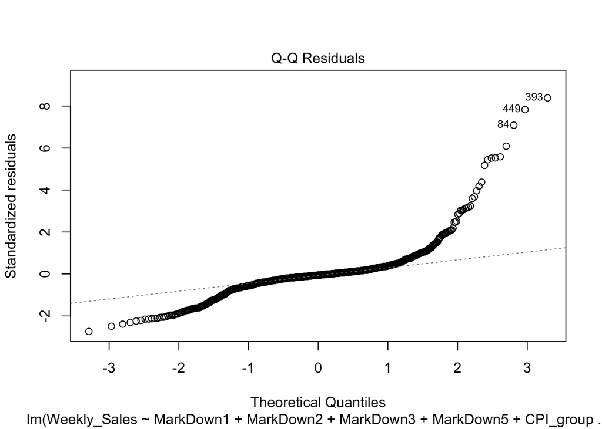

```r
plot(lm.all.train, which=1:2)
```

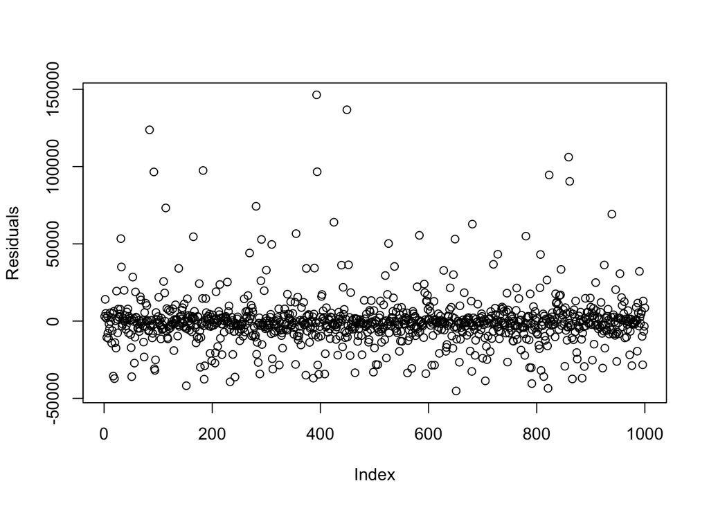

```r
plot(lm.all.train$residuals, ylab="Residuals")
```

## Transformation

Once I made the decision to employ a transformation, I initially utilized the boxCox function to determine the appropriate value of λ. This process aimed to assist me in selecting the most suitable transformation for my data.

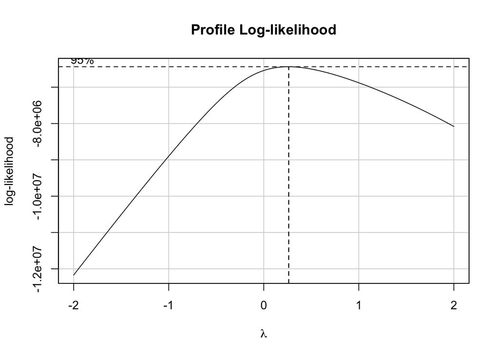

```r
library(car)
sales_features_no_na$Weekly_Sales2 <- ifelse(sales_features_no_na$Weekly_Sales <1, 1,sales_features_no_na$Weekly_Sales)


boxCox(lm(Weekly_Sales2 ~
              #I(Temperature^2) +
              MarkDown1 +
              MarkDown2 +
              MarkDown3 +
              MarkDown5 +
              CPI_group +
              Unemployment +
              dept_group, data=sales_features_no_na))
```

```r
lmt <- lm(sqrt(sqrt(Weekly_Sales2)) ~
              #I(Temperature^2) +
              MarkDown1 +
              MarkDown2 +
              MarkDown3 +
              MarkDown5 +
              CPI_group +
              Unemployment +
              dept_group, data=sales_features_no_na)
summary(lmt)
```

```
Call:
lm(formula = sqrt(sqrt(Weekly_Sales2)) ~ MarkDown1 + MarkDown2 +
    MarkDown3 + MarkDown5 + CPI_group + Unemployment + dept_group,
    data = sales_features_no_na)

Residuals:
     Min       1Q   Median       3Q      Max
-29.9041  -1.2723   0.3212   1.6697  15.9256

Coefficients:
                   Estimate Std. Error t value Pr(>|t|)
(Intercept)       7.204e-01  1.117e-01   6.451 1.11e-10 ***
MarkDown1         3.067e-05  7.539e-07  40.680  < 2e-16 ***
MarkDown2         1.216e-05  8.288e-07  14.672  < 2e-16 ***
MarkDown3         2.060e-05  7.450e-07  27.653  < 2e-16 ***
MarkDown5         3.272e-05  1.044e-06  31.339  < 2e-16 ***
CPI_group2        5.665e+00  1.137e-01  49.829  < 2e-16 ***
CPI_group3        5.613e+00  1.138e-01  49.320  < 2e-16 ***
CPI_group4        5.238e+00  1.133e-01  46.220  < 2e-16 ***
Unemployment     -1.027e-01  2.346e-03 -43.793  < 2e-16 ***
dept_groupgroup2  2.771e+00  1.164e-02 237.990  < 2e-16 ***
dept_groupgroup3  4.293e+00  1.379e-02 311.268  < 2e-16 ***
dept_groupgroup4  5.240e+00  1.637e-02 320.152  < 2e-16 ***
dept_groupgroup5  7.468e+00  1.186e-02 629.598  < 2e-16 ***
---
Signif. codes:  0 '***' 0.001 '**' 0.01 '*' 0.05 '.' 0.1 ' ' 1

Residual standard error: 2.699 on 423312 degrees of freedom
Multiple R-squared:  0.5081,    Adjusted R-squared:  0.5081
F-statistic: 3.644e+04 on 12 and 423312 DF,  p-value: < 2.2e-16
```

Here’s my updated model post-transformation, indicating an improved adjusted R-square of 50%, which I find quite satisfying. However, I still need to verify whether the transformation has effectively addressed the issues observed in my diagnostic plots and also my validation r-square.

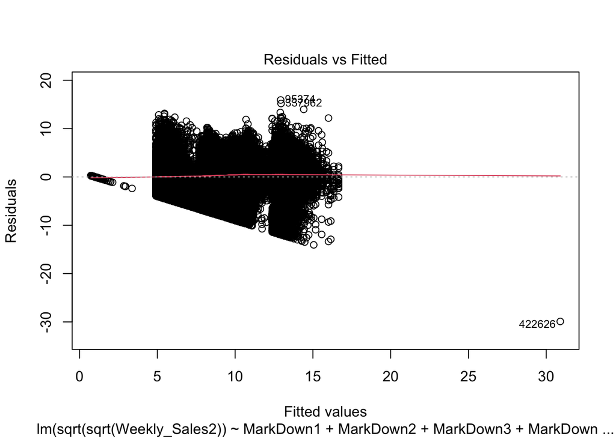

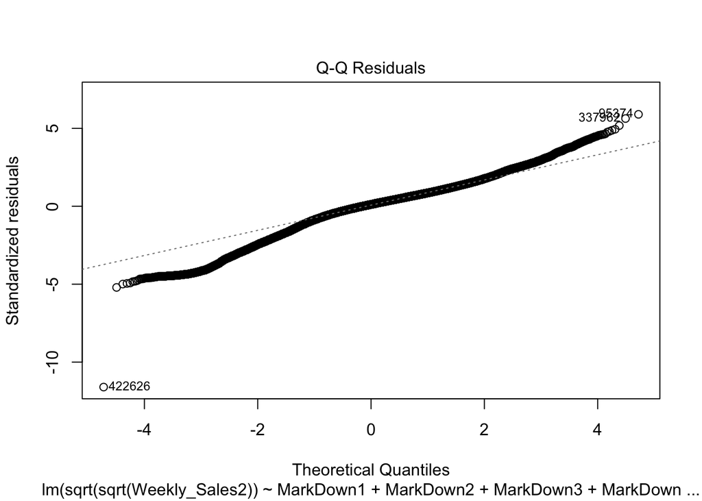

```r
plot(lmt, which=1:2)
```

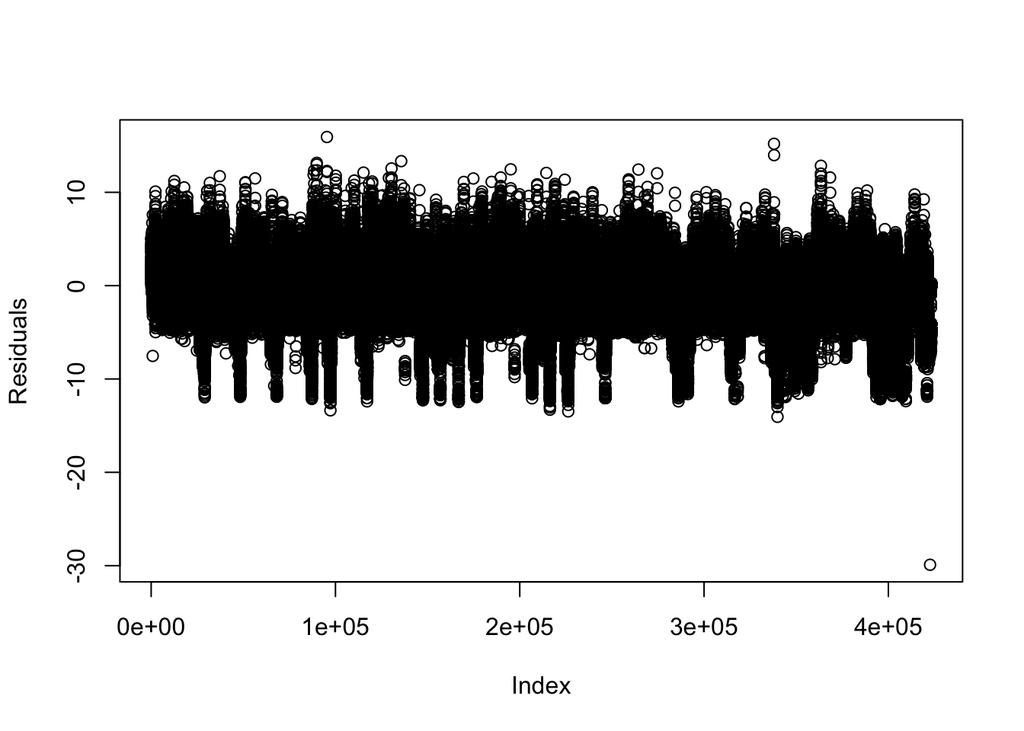

```r
plot(lmt$residuals, ylab="Residuals")
```

```r
num_rows <- round(423325*.70)
keep <- sample(1:nrow(sales_features_no_na), num_rows)

mytrain <- sales_features_no_na[keep, ] #Use this in the lm(..., data=mytrain) it is like "rbdata"

mytest <- sales_features_no_na[-keep, ]

lm.all.train <- lm(sqrt(sqrt(Weekly_Sales2))~
              #I(Temperature^2) +
              MarkDown1 +
              MarkDown2 +
              MarkDown3 +
              MarkDown5 +
              CPI_group +
              Unemployment +
              dept_group,
            data = mytrain)



yht <- predict(lm.all.train, newdata=mytest)^4

  # Compute y-bar
  ybar <- mean(mytest$Weekly_Sales) #Yi is given by Ynew from the new sample of data

  # Compute SSTO
  SSTO <- sum( (mytest$Weekly_Sales - ybar)^2 )

  # Compute SSE for each model using y - yhat
  SSEt <- sum( (mytest$Weekly_Sales - yht)^2 )


  # Compute R-squared for each
  rst <- 1 - SSEt/SSTO


  # Compute adjusted R-squared for each
  n <- length(mytest$Weekly_Sales) #sample size
  pt <- length(coef(lm.all.train)) #num. parameters in model

  rsta <- 1 - (n-1)/(n-pt)*SSEt/SSTO



my_output_table2 <- data.frame(Model = c("True"), `Original R2` = c( summary(lm.all.train)$r.squared), `Orig. Adj. R-squared` = c( summary(lm.all.train)$adj.r.squared), `Validation R-squared` = c(rst), `Validation Adj. R^2` = c(rsta))

colnames(my_output_table2) <- c("Model", "Original $R^2$", "Original Adj. $R^2$", "Validation $R^2$", "Validation Adj. $R^2$")

knitr::kable(my_output_table2, escape=TRUE, digits=4)
```

| Model | Original $R^2$ | Original Adj. $R^2$ | Validation $R^2$ | Validation Adj. $R^2$ |
| --- | --- | --- | --- | --- |
| True | 0.5088 | 0.5088 | 0.3483 | 0.3482 |

Observing the validation R-square, it’s apparent that it has significantly worsened. Coupled with the persisting issues in my diagnostic plots, it’s clear that employing the transformation is not suitable for my model.

## Conditions

Based on my model, I have created the graph below with specific conditions to enhance understanding and interpretation for individuals.

The five distinct lines in the graph correspond to department groups 1 through 5. It’s observable that department group 1 has the smallest y-intercept and is positioned at the lower end, while department group 5 exhibits the highest y-intercept, indicating the largest sales volume. This discrepancy implies that different departments within Walmart might exhibit varying levels of weekly sales. Unfortunately, due to the dataset’s lack of specific department information, determining which departments these groups represent is challenging. However, according to data from Statista, the grocery department stands out with the highest sales, potentially aligning with department group 5. Nevertheless, without explicit details in the dataset, definitive conclusions cannot be drawn regarding the department representation.

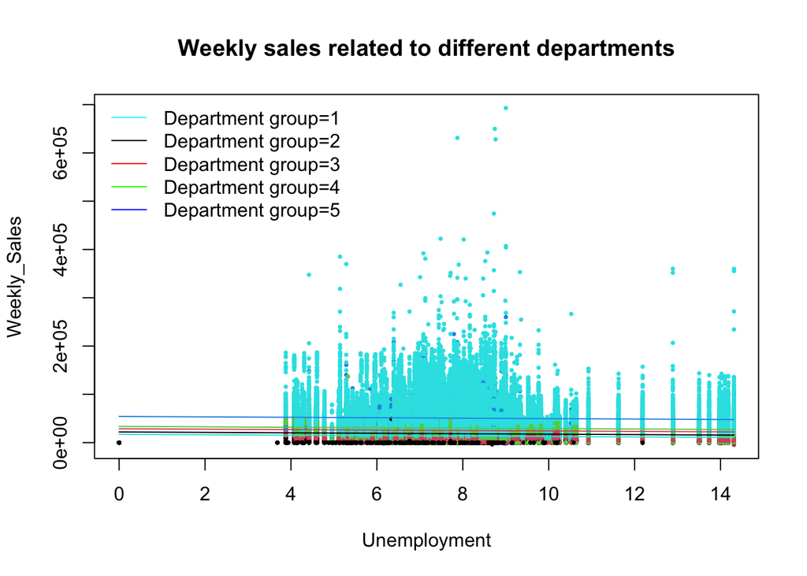

```r
plot(Weekly_Sales ~ Unemployment,
     data=sales_features_no_na,
     pch = 16,
     cex = 0.5,
     col=as.factor(dept_group),main="Weekly sales related to different departments")
legend("topleft", bty="n", legend=c("Department group=1","Department group=2", "Department group=3", "Department group=4","Department group=5"), col=c("cyan","black","red","green","blue"), lty=1)


b <- coef(mylm8)


MarkDown1=1;MarkDown2=1;MarkDown3=1;MarkDown5=1;CPI_group2=1;CPI_group3=1;CPI_group4=1;Unemployment=1;dept_groupgroup2=0;dept_groupgroup3=0;dept_groupgroup4=0;dept_groupgroup5=0;i=5
#drawit <- function(MarkDown1, MarkDown2, MarkDown3, MarkDown5,CPI_group,Unemployment,dept_group )
curve(b[1] + b[2]*MarkDown1+ b[3]*MarkDown2 + b[4]*MarkDown3+ b[5]*MarkDown5 + b[6]*CPI_group2 + b[7]*CPI_group3 + b[8]*CPI_group4 + b[9]*Unemployment + b[10]*dept_groupgroup2 + b[11]*dept_groupgroup3 + b[12]*dept_groupgroup4 + b[13]*dept_groupgroup5, xname="Unemployment",col=palette()[i], add=TRUE)

MarkDown1=1;MarkDown2=1;MarkDown3=1;MarkDown5=1;CPI_group2=1;CPI_group3=1;CPI_group4=1;Unemployment=1;dept_groupgroup2=1;dept_groupgroup3=0;dept_groupgroup4=0;dept_groupgroup5=0;i=1
#drawit <- function(MarkDown1, MarkDown2, MarkDown3, MarkDown5,CPI_group,Unemployment,dept_group )
curve(b[1] + b[2]*MarkDown1+ b[3]*MarkDown2 + b[4]*MarkDown3+ b[5]*MarkDown5 + b[6]*CPI_group2 + b[7]*CPI_group3 + b[8]*CPI_group4 + b[9]*Unemployment + b[10]*dept_groupgroup2 + b[11]*dept_groupgroup3 + b[12]*dept_groupgroup4 + b[13]*dept_groupgroup5, xname="Unemployment",col=palette()[i], add=TRUE)


MarkDown1=1;MarkDown2=1;MarkDown3=1;MarkDown5=1;CPI_group2=1;CPI_group3=1;CPI_group4=1;Unemployment=1;dept_groupgroup2=0;dept_groupgroup3=1;dept_groupgroup4=0;dept_groupgroup5=0;i=2
curve(b[1] + b[2]*MarkDown1+ b[3]*MarkDown2 + b[4]*MarkDown3+ b[5]*MarkDown5 + b[6]*CPI_group2 + b[7]*CPI_group3 + b[8]*CPI_group4 + b[9]*Unemployment + b[10]*dept_groupgroup2 + b[11]*dept_groupgroup3 + b[12]*dept_groupgroup4 + b[13]*dept_groupgroup5, xname="Unemployment",col=palette()[i], add=TRUE)


MarkDown1=1;MarkDown2=1;MarkDown3=1;MarkDown5=1;CPI_group2=1;CPI_group3=1;CPI_group4=1;Unemployment=1;dept_groupgroup2=0;dept_groupgroup3=0;dept_groupgroup4=1;dept_groupgroup5=0;i=3
curve(b[1] + b[2]*MarkDown1+ b[3]*MarkDown2 + b[4]*MarkDown3+ b[5]*MarkDown5 + b[6]*CPI_group2 + b[7]*CPI_group3 + b[8]*CPI_group4 + b[9]*Unemployment + b[10]*dept_groupgroup2 + b[11]*dept_groupgroup3 + b[12]*dept_groupgroup4 + b[13]*dept_groupgroup5, xname="Unemployment",col=palette()[i], add=TRUE)


MarkDown1=1;MarkDown2=1;MarkDown3=1;MarkDown5=1;CPI_group2=1;CPI_group3=1;CPI_group4=1;Unemployment=1;dept_groupgroup2=0;dept_groupgroup3=0;dept_groupgroup4=0;dept_groupgroup5=1;i=4
curve(b[1] + b[2]*MarkDown1+ b[3]*MarkDown2 + b[4]*MarkDown3+ b[5]*MarkDown5 + b[6]*CPI_group2 + b[7]*CPI_group3 + b[8]*CPI_group4 + b[9]*Unemployment + b[10]*dept_groupgroup2 + b[11]*dept_groupgroup3 + b[12]*dept_groupgroup4 + b[13]*dept_groupgroup5, xname="Unemployment",col=palette()[i], add=TRUE)
```

## Prediction

Utilizing the model I developed enables the prediction of Walmart’s weekly sales. For instance, under specific conditions—such as a CPI rate ranging from 10 to 150, an unemployment rate of 1, and department group 2—the projected weekly sales for Walmart fall within the range of $200.4 to $42,331.

```r
mypred<- predict(lmt, data.frame(MarkDown1=0,MarkDown2=0,MarkDown3=0,MarkDown5=0,CPI_group="2",Unemployment=1,dept_group="group2"), interval="prediction")^4
library(pander)
pander(mypred)
```

| fit | lwr | upr |
| --- | --- | --- |
| 6717 | 200.4 | 42331 |

## Furture Study

In future studies, my aim is to enhance the validation R-square to develop a superior model that aligns more accurately with market trends. Additionally, I aspire to acquire additional dataset information to further clarify and improve interpretability.

Back to top